# Insights Communication

When the confidence levels of first,second and third prediction change, the frequency of dogs in the dataset changes accordingly

This will be demonstrated in the next line of codes

Filtering data by rows where the algorithm's prediction is equal to or greater than 95% and the prediction is a breed of dog and the tweet wasn't retweeted

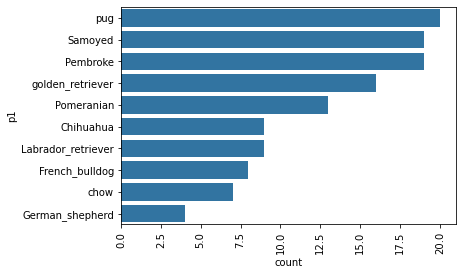

```python
sb.countplot(y = 'p1', data = filtered_df_0,  color = base_color, order = gen_order[:10]);
plt.xticks(rotation = 90);
```

The above chart shows that when confidence level (i.e column 'p1_conf') is greater than or equals to 95%, the order of frequency of the first 10 dogs are pug,Samoyed,Pembroke,golden retriever, Pomeranian, Chihuahua,Labrador Retriever, French Bulldong, Chow, and German Shepherd in that order. In the next line of code I will be reducing the confidence levels to equal or greater than 90% to identify visible difference

Filtering data by rows where the algorithm's prediction is equal to or greater than 90% and the prediction is a breed of dog and the tweet wasn't retweeted

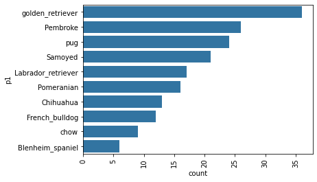

```python
sb.countplot(y = 'p1', data = filtered_df_1,  color = base_color, order = gen_order[:10]);
plt.xticks(rotation = 90);
```

The above chart shows that when confidence level (i.e column 'p1_conf') is greater than or equals to 90%, the order of frequency of the first 10 dogs are golden retriever,Pembroke,pug,Samoyed,Labrador Retriever, Pomeranian,Chihuahua, French Bulldong, Chow, and Blenheim_spaniel in that order.

# The major differences between the two charts are outlined below

- `Pug:` In the first chart, pug had the highest frequency however when the confidence level changed it became third in the order of frequency
- `Samoyed:` In the first chart, Samoyed was second in the order of frequency however when the confidence level changed, it became the fourth in the order of frequency
- `Pembroke:` Pembroke was third in the order of frequency in the first chart, and it became second in the second chart in the order of frequency
- `Golden Retriever:` This was the fourth dog in the order of frequency in the first chart and it became the first dog in the order of frequency when the confidence level changes as displaed in the second chart
- `Pomeranian:` This was the fifth dog in the order of frequency in the first chart however it changed to the sixth dog in order of frequency in the second chart
- `Labrador Retriever:` This was the seventh dog in order of frequency in the first chart however this changed by moving up to be the fifth dog in the order of frequency in the second as displayed in the second chart